# TP1 : Modèle linéaire général (Rappel)

LBIR2222

janvier 12, 2026

# 1 Contexte et plan d’expérience

Lors d’une expérience en serre, une chercheuse souhaite estimer l’impact de différents régimes d’irrigation sur la croissance de plants de maïs de variétés différentes. Sa serre étant bordée d’arbres au sud-ouest, les plants sont soumis à des expositions différentes susceptibles d’impacter leur croissance. Elle décide donc de prendre en compte l’intensité lumineuse à laquelle sont soumis ses plants. Elle fait donc l’expérience suivante :

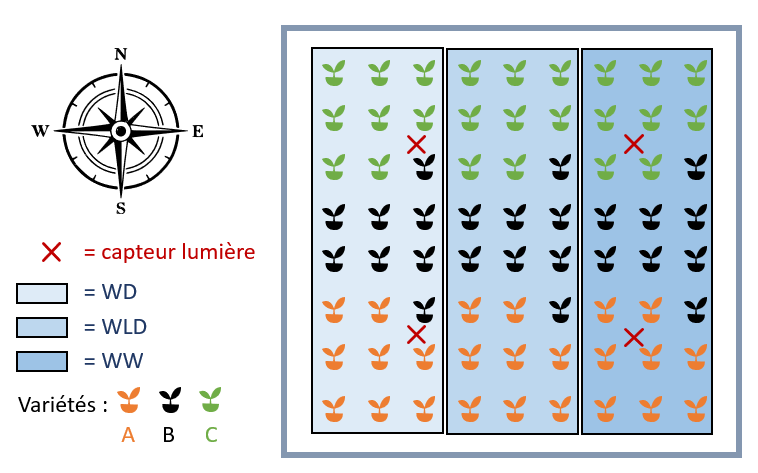

Elle rassemble ensuite ces données dans un fichier CSV (Comma Separated Values) et nous demande de les analyser. Nous avons donc 72 lignes pour les variables suivantes:

**M**: Biomasse accumulée sur une semaine ( FW [g/plant])  
**PPFD**: PPFD cumulé sur une semaine (mol/m²)  
**W**: régime d’irrigation (WW=Well Watered, WLD=Water light deficit, WD=Water deficit)  
**V**: Variété (A, B ou C)

Note 1 : Le PPFD (Photosynthetic Photon Flux Density) est le nombre de photons dans la gamme de fréquence de 400 à 700 nm par unité de temps sur une unité de surface.

Note 2 : Il s’agit d’un plan factoriel complet avec huits répétitions : $3(lvl_W)*3(lvl_V)*8(répétitions)=72$

# 2 Importation et exploration des données

```r
mydata <- read.csv("plant_growth_data.csv")
```

Avant toute chose, il s’agit d’explorer et de visualiser vos données afin d’avoir un premier apperçu des variables et éventuels problèmes que vous pourriez rencontrer.

- Déterminez combien de plantes sont testées pour chaque niveau des deux facteurs catégoriels

Commencez par un rapide résumé (à l’aide de `str()`, `summary()` ou `table()` par exemple):

```r
pander(summary(mydata)) # pour avoir quelques informations sur les données
```

| M | PPFD | W | V |
| --- | --- | --- | --- |
| Min. :125.2 | Min. :136.0 | Length:72 | Length:72 |
| 1st Qu.:182.9 | 1st Qu.:144.2 | Class :character | Class :character |
| Median :212.6 | Median :169.5 | Mode :character | Mode :character |
| Mean :223.2 | Mean :171.5 |  |  |
| 3rd Qu.:248.6 | 3rd Qu.:196.8 |  |  |
| Max. :360.6 | Max. :211.0 |  |  |

```r
table(mydata[, c("W")]) # si on veut regarder le nombre d'observation pour un seul facteur
```

```
 WD WLD  WW
 24  24  24
```

```r
table(mydata[, c("V")])
```

```
 A  B  C
24 24 24
```

```r
#NB: table(mydata[, c("W","V", "PPFD")]) # si on veut le nombre d'observation par traitement (combinaison des facteurs)
```

A l’aide de ce résumé nous pouvons conclure que 24 plantes sont testées pour chacun des niveaux des facteurs W et V.

- Représentez vos données en représentant les différents niveaux des facteurs à l’aide de couleurs ou de formes (avec un `ggplot()`)

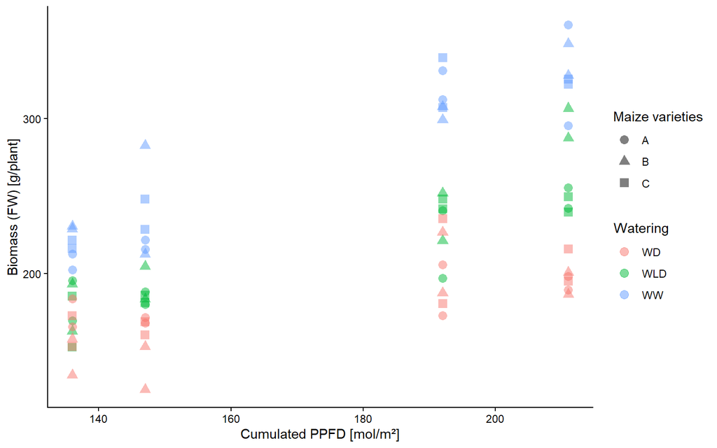

```r
ggplot(mydata,aes(x=PPFD,y=M,color=W, shape=V)) + geom_point(alpha = 0.5, size=3) +
               labs(shape="Maize varieties",
                    color = "Watering",
                    x= "Cumulated PPFD [mol/m²]",
                    y= "Biomass (FW) [g/plant]")
```

# 3 Modélisation

Comme vous suspectez des interactions entre les effets des trois variables explicatives, vous aimeriez estimer un modèle linéaire général complet.

## 3.1 Premier modèle

Testez un premier modèle contenant les trois variables et toutes leurs interactions. Sur base des résultats de l’analyse ANOVA, quels sont les facteurs qui sont significatifs ?

```r
mod <- lm(M ~ PPFD * W * V, mydata)
anova(mod)
```

```
Analysis of Variance Table

Response: M
          Df Sum Sq Mean Sq  F value    Pr(>F)
PPFD       1  83842   83842 242.0816 < 2.2e-16 ***
W          2 111637   55818 161.1677 < 2.2e-16 ***
V          2    450     225   0.6497    0.5262
PPFD:W     2  10445    5222  15.0792 6.266e-06 ***
PPFD:V     2    711     356   1.0272    0.3649
W:V        4   2375     594   1.7141    0.1603
PPFD:W:V   4   2368     592   1.7095    0.1613
Residuals 54  18702     346
---
Signif. codes:  0 '***' 0.001 '**' 0.01 '*' 0.05 '.' 0.1 ' ' 1
```

On observe que la variété (V) n’est pas un facteur significatif pour expliquer la croissance des plantes. Par contre les facteurs PPFD et W (niveau d’irrigation) ainsi que leur interaction sont significatifs.

N’oubliez pas de vérifier que le modèle respecte les hypothèses de l’ANOVA.

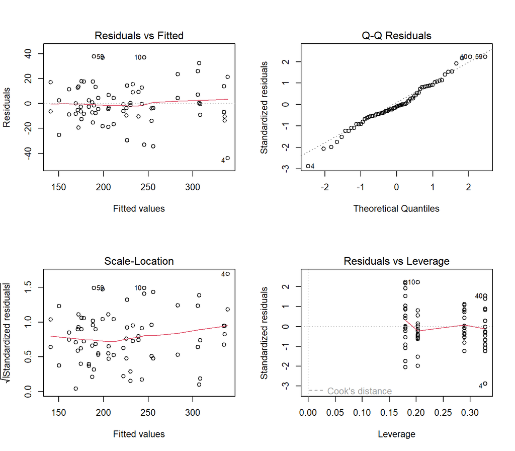

```r
par(mfrow = c(2,2))
plot(mod)
```

```r
par(mfrow=c(1,1))
```

La commande `plot(mod)` affiche **quatre graphiques de diagnostic** qui permettent de vérifier si les **hypothèses du modèle linéaire** sont raisonnablement respectées.

### 3.1.1 Résidus vs valeurs ajustées (Residuals vs Fitted)

Ce graphique permet de vérifier :

- la **linéarité** de la relation,
- l’**homoscédasticité** (variance constante des résidus).

Les résidus doivent être répartis **de manière aléatoire autour de 0**, sans forme particulière.  
Une courbure suggère une relation non linéaire.  
Une forme en éventail indique une variance non constante.

**Ici, la répartition des points sur le graphique ressemblent à une sorte de patate, ce qui est bien**. On observe uniquement 2-3 points (59, 10, 4) qui s’éloignent légèrement. Il faudrait idéalement consulter la chercheuse pour savoir si ces valeurs sont des potentiels outliers ou pas.

### 3.1.2 QQ-plot des résidus (Normal Q-Q)

Ce graphique sert à vérifier la **normalité des résidus**.

Les points doivent suivre approximativement la **droite de référence**.  
Des écarts importants, indiquent une non-normalité des résidus.

**Ici, la répartition des points suivent majoritairement la droite de référence**. On observe que les données sont légèrement plus éparpillées sur les extrémités, et que la droite suit légèrement une forme en “S”. Ceci est souvent le cas et peut être considéré comme acceptable pour une expérience en agronomie. De nouveau, certains points (59, 10, 4) s’éloignent de la courbe de référence (cfr. commentaire précédant).

### 3.1.3 Scale-Location (√|résidus| vs valeurs ajustées)

Ce graphique permet aussi d’évaluer l’**homoscédasticité** (voir “Residuals vs Fitted”).

La dispersion des points doit être **à peu près constante** le long de l’axe horizontal.  
Une tendance croissante ou décroissante indique que la variance des résidus dépend du niveau des valeurs ajustées.

**Ici, la répartition des points sur le graphique ressemble à une sorte de patate, ce qui est bien** (cfr.”Residuals vs Fitted”).

### 3.1.4 Résidus vs leverage (distance de Cook)

Ce graphique permet d’identifier les **observations influentes** (càd dont la suppression où l’ajout de l’observation influence fortement les résultats du modèle).

Une observation influente combine deux choses :

- un **résidu élevé** (point mal expliqué),
- un **leverage élevé** (point situé dans une zone peu représentée des X).

Une observation est influente seulement si les deux sont grands. Pour interpréter ce graphique, il faut que la ligne rouge (une courbe de lissage des résidus vs. leverage) reste plus ou moins linéaire (cela veut dire qu’il n’y a pas de point qui l’influence fortement).  
**Dans notre cas, on voit qu’elle déscend légèrement au début, mais reste ensuite horizontale.** C’est donc acceptable.

## 3.2 Deuxième modèle

Sur base des résultats de l’ANOVA sur le premier modèle, ajustez votre modèle et refaites une nouvelle ANOVA. Que pouvez-vous en conclure ? Nous allons réaliser un nouveau modèle sans le facteur variété :

```r
mod <- lm(M ~ PPFD * W , mydata)
summary(mod)
```

```
Call:
lm(formula = M ~ PPFD * W, data = mydata)

Residuals:
   Min     1Q Median     3Q    Max
-41.48 -11.56  -3.09  11.17  46.80

Coefficients:
            Estimate Std. Error t value Pr(>|t|)
(Intercept)  74.7621    22.1664   3.373  0.00125 **
PPFD          0.6110     0.1272   4.804 9.34e-06 ***
WWLD        -53.5261    31.3480  -1.707  0.09243 .
WWW         -67.5980    31.3480  -2.156  0.03470 *
PPFD:WWLD     0.5201     0.1799   2.891  0.00519 **
PPFD:WWW      0.9507     0.1799   5.285 1.52e-06 ***
---
Signif. codes:  0 '***' 0.001 '**' 0.01 '*' 0.05 '.' 0.1 ' ' 1

Residual standard error: 19.31 on 66 degrees of freedom
Multiple R-squared:  0.8933,    Adjusted R-squared:  0.8852
F-statistic: 110.5 on 5 and 66 DF,  p-value: < 2.2e-16
```

```r
anova(mod)
```

```
Analysis of Variance Table

Response: M
          Df Sum Sq Mean Sq F value    Pr(>F)
PPFD       1  83842   83842 224.882 < 2.2e-16 ***
W          2 111637   55818 149.717 < 2.2e-16 ***
PPFD:W     2  10445    5222  14.008 8.498e-06 ***
Residuals 66  24607     373
---
Signif. codes:  0 '***' 0.001 '**' 0.01 '*' 0.05 '.' 0.1 ' ' 1
```

Nous constatons que l’adaptation faite dans le modèle 2 semble plus intéressante puisque tous les effets sont significatifs. Cependant, nous pouvont observer que la $Sum Sq$ des résidus a augmenté. Effectivement, lorsque nous avons enlevé le facteur variété, une part de la variabilité expliquée par ce facteur (même si non significative) se retrouve maintenant dans la variabilité résiduelle.

Avant d’aller plus loin, vérifiez bien que vous comprenez chacune des valeurs données dans ce tableau ainsi que les tests effectués.

## 3.3 Vérification des hypothèses sous-jacentes au modèle

Avant de se lancer dans l’interprétation de votre modèle, vérifiez bien les hypothèses sous-jacentes à la régression (Normalité, indépendance des données, constance de la variance). Ces hypothèses sont-elles respectées ?

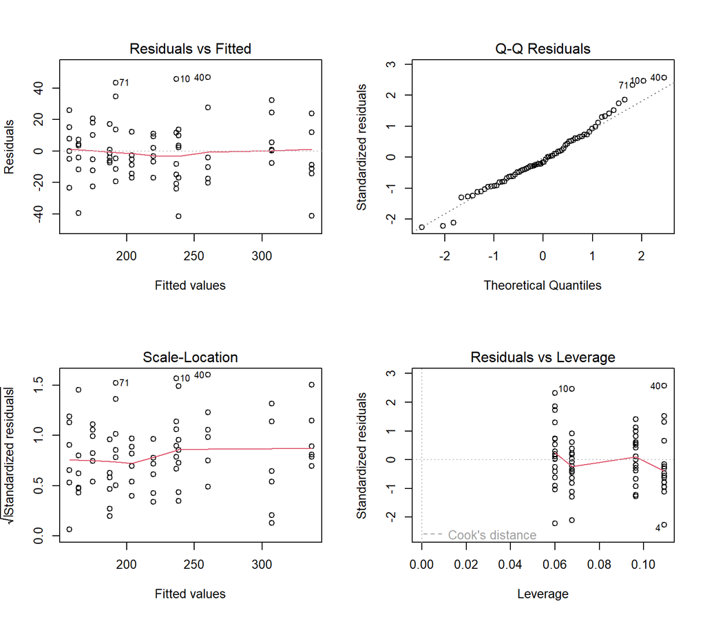

```r
par(mfrow = c(2,2))
plot(mod)
```

```r
par(mfrow=c(1,1))
```

Pour l’interprétation, les résultats sont assez proches de ceux observés avec le premier modèle. Nous pouvons donc considérer que les hypothèses sont respectées (malgré quelques outliers potentiels).

## 3.4 Visualisation du modèle avec intervalles de confiance

Lorsque vous visualisez votre modèle, soyez attentifs aux labels des axes et au titre de la légende. Les intervales affichés sont les intervales de confiance pour la réponse moyenne (IC au modèle). Quelle information déjà observée dans l’ANOVA vous montrent les pentes des droites ?

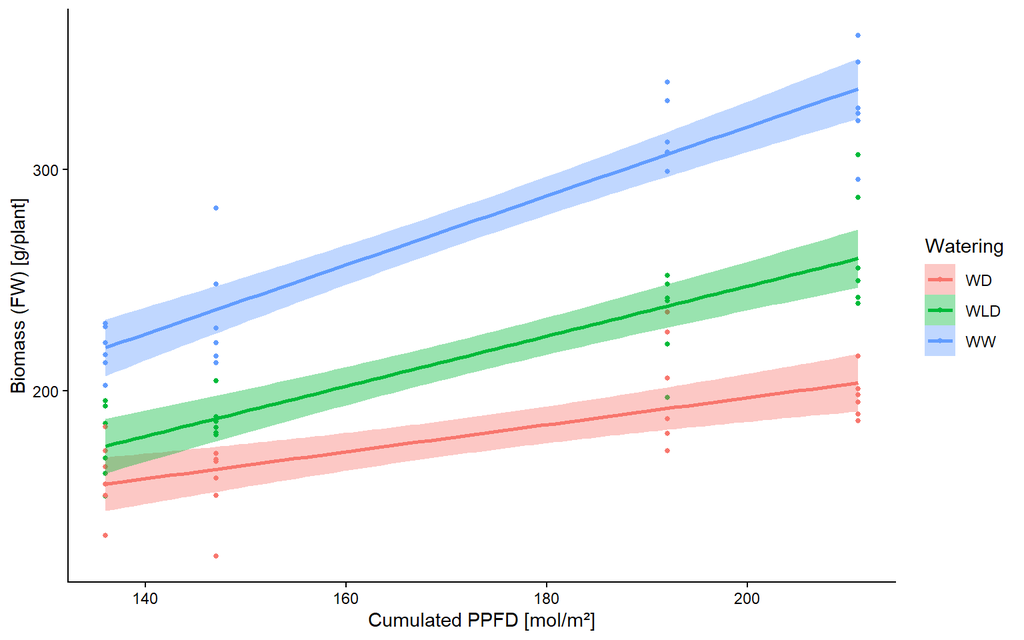

```r
ggplot(mydata, aes(x=PPFD,y=M,color=W, fill=W)) + geom_point(size=1) +  geom_smooth(method = 'lm') +
               labs(x= "Cumulated PPFD [mol/m²]", y= "Biomass (FW) [g/plant]")+
               guides(fill=guide_legend("Watering"), color=guide_legend("Watering"))
```

Des droites de pentes différentes indiquent une interaction entre l’effet du PPFD et du régime d’irrigation.

# 4 Prédictions

Notre chercheuse aimerait prédire la croissance de ses plants de maïs lorsque le PPFD est de 150 ou 200, avec un régime d’irrigation WW ou WD (bien irrigué ou déficit en eau). Utilisez votre modèle pour effectuer cette prédiction pour toutes les combinaisons possibles de ces valeurs. Calculez aussi l’intervalle de confiance pour la réponse moyenne et l’intervale de prédiction pour chacune de ces situations.

## 4.1 Intervale de confiance pour la réponse moyenne (IC au modèle)

```r
xpred <- data.frame("W" = c("WW","WD","WW","WD"),
                  "PPFD" = c(150, 150, 200, 200))
modIC <- predict(mod, newdata = xpred, interval = "confidence")

res <- data.frame(xpred, modIC)
pander(res)
```

| W | PPFD | fit | lwr | upr |
| --- | --- | --- | --- | --- |
| WW | 150 | 241.4 | 231.8 | 251 |
| WD | 150 | 166.4 | 156.8 | 176 |
| WW | 200 | 319.5 | 308.8 | 330.2 |
| WD | 200 | 197 | 186.3 | 207.6 |

## 4.2 Intervale de prédiction (IC aux valeurs)

```r
predIC <- predict(mod, newdata = xpred, interval = "prediction")

res <- data.frame(xpred, predIC)
pander(res)
```

| W | PPFD | fit | lwr | upr |
| --- | --- | --- | --- | --- |
| WW | 150 | 241.4 | 201.7 | 281.1 |
| WD | 150 | 166.4 | 126.7 | 206.1 |
| WW | 200 | 319.5 | 279.5 | 359.5 |
| WD | 200 | 197 | 156.9 | 237 |

# 5 Matrice X

On peut afficher la matrice **X** utilisée par R pour estimer le modèle à l’aide de `model.matrix()`. Quelle différence avec la matrice de votre modèle de régression telle que vue au cours? Pourquoi ?

```r
pander(model.matrix(mod))
```

| (Intercept) | PPFD | WWLD | WWW | PPFD:WWLD | PPFD:WWW |
| --- | --- | --- | --- | --- | --- |
| 1 | 136 | 0 | 1 | 0 | 136 |
| 1 | 147 | 0 | 1 | 0 | 147 |
| 1 | 192 | 0 | 1 | 0 | 192 |
| 1 | 211 | 0 | 1 | 0 | 211 |
| 1 | 136 | 0 | 1 | 0 | 136 |
| 1 | 147 | 0 | 1 | 0 | 147 |
| 1 | 192 | 0 | 1 | 0 | 192 |
| 1 | 211 | 0 | 1 | 0 | 211 |
| 1 | 136 | 0 | 1 | 0 | 136 |
| 1 | 147 | 0 | 1 | 0 | 147 |
| 1 | 192 | 0 | 1 | 0 | 192 |
| 1 | 211 | 0 | 1 | 0 | 211 |
| 1 | 136 | 0 | 1 | 0 | 136 |
| 1 | 147 | 0 | 1 | 0 | 147 |
| 1 | 192 | 0 | 1 | 0 | 192 |
| 1 | 211 | 0 | 1 | 0 | 211 |
| 1 | 136 | 0 | 1 | 0 | 136 |
| 1 | 147 | 0 | 1 | 0 | 147 |
| 1 | 192 | 0 | 1 | 0 | 192 |
| 1 | 211 | 0 | 1 | 0 | 211 |
| 1 | 136 | 0 | 1 | 0 | 136 |
| 1 | 147 | 0 | 1 | 0 | 147 |
| 1 | 192 | 0 | 1 | 0 | 192 |
| 1 | 211 | 0 | 1 | 0 | 211 |
| 1 | 136 | 1 | 0 | 136 | 0 |
| 1 | 147 | 1 | 0 | 147 | 0 |
| 1 | 192 | 1 | 0 | 192 | 0 |
| 1 | 211 | 1 | 0 | 211 | 0 |
| 1 | 136 | 1 | 0 | 136 | 0 |
| 1 | 147 | 1 | 0 | 147 | 0 |
| 1 | 192 | 1 | 0 | 192 | 0 |
| 1 | 211 | 1 | 0 | 211 | 0 |
| 1 | 136 | 1 | 0 | 136 | 0 |
| 1 | 147 | 1 | 0 | 147 | 0 |
| 1 | 192 | 1 | 0 | 192 | 0 |
| 1 | 211 | 1 | 0 | 211 | 0 |
| 1 | 136 | 1 | 0 | 136 | 0 |
| 1 | 147 | 1 | 0 | 147 | 0 |
| 1 | 192 | 1 | 0 | 192 | 0 |
| 1 | 211 | 1 | 0 | 211 | 0 |
| 1 | 136 | 1 | 0 | 136 | 0 |
| 1 | 147 | 1 | 0 | 147 | 0 |
| 1 | 192 | 1 | 0 | 192 | 0 |
| 1 | 211 | 1 | 0 | 211 | 0 |
| 1 | 136 | 1 | 0 | 136 | 0 |
| 1 | 147 | 1 | 0 | 147 | 0 |
| 1 | 192 | 1 | 0 | 192 | 0 |
| 1 | 211 | 1 | 0 | 211 | 0 |
| 1 | 136 | 0 | 0 | 0 | 0 |
| 1 | 147 | 0 | 0 | 0 | 0 |
| 1 | 192 | 0 | 0 | 0 | 0 |
| 1 | 211 | 0 | 0 | 0 | 0 |
| 1 | 136 | 0 | 0 | 0 | 0 |
| 1 | 147 | 0 | 0 | 0 | 0 |
| 1 | 192 | 0 | 0 | 0 | 0 |
| 1 | 211 | 0 | 0 | 0 | 0 |
| 1 | 136 | 0 | 0 | 0 | 0 |
| 1 | 147 | 0 | 0 | 0 | 0 |
| 1 | 192 | 0 | 0 | 0 | 0 |
| 1 | 211 | 0 | 0 | 0 | 0 |
| 1 | 136 | 0 | 0 | 0 | 0 |
| 1 | 147 | 0 | 0 | 0 | 0 |
| 1 | 192 | 0 | 0 | 0 | 0 |
| 1 | 211 | 0 | 0 | 0 | 0 |
| 1 | 136 | 0 | 0 | 0 | 0 |
| 1 | 147 | 0 | 0 | 0 | 0 |
| 1 | 192 | 0 | 0 | 0 | 0 |
| 1 | 211 | 0 | 0 | 0 | 0 |
| 1 | 136 | 0 | 0 | 0 | 0 |
| 1 | 147 | 0 | 0 | 0 | 0 |
| 1 | 192 | 0 | 0 | 0 | 0 |
| 1 | 211 | 0 | 0 | 0 | 0 |

R a enlevé un niveau de chaque facteur afin d’avoir une matrice inversible.

# 6 Pour rappel, vous vous intéressez à connaître l’effet du niveau d’irrigation sur la biomasse des plants de maïs. Sur base des résultats que vous avez, que pouvez-vous dire ? N’hésitez pas à utiliser les fonctions `emmeans()` et `ref_grid()` pour illustrer vos explications ?

Lorsque l’on fait un `emmeans()`, nous observons qu’il y a des différences significatives entre les biomasses en fonction de si W= WD, WLD, WW. De manière générale, une plante qui reçoit plus d’eau aura une biomasse plus élevée.

Cependant, comme l’indique la console de R, ces comparaisons sont effectuées pour un PPFD moyen de 172 mol/m². Hors, nous savons que nos données ne se comportent pas de la même manière si la valeur de PPFD est faible ou élevée (cfr. intéraction W*PPFD). Ce test est donc à prendre avec des pincettes !

```r
emm_s.t <- emmeans(mod, pairwise ~ W | PPFD)
emm_s.t
```

```
$emmeans
PPFD = 172:
 W   emmean   SE df lower.CL upper.CL
 WD     180 3.94 66      172      187
 WLD    215 3.94 66      207      223
 WW     275 3.94 66      267      283

Confidence level used: 0.95

$contrasts
PPFD = 172:
 contrast estimate   SE df t.ratio p.value
 WD - WLD    -35.7 5.57 66  -6.399  <.0001
 WD - WW     -95.4 5.57 66 -17.123  <.0001
 WLD - WW    -59.8 5.57 66 -10.724  <.0001

P value adjustment: tukey method for comparing a family of 3 estimates
```

Nous pouvons calculer les valeurs estimées pour chaque valeur de PPFD :

```r
mod.rg1 <- pairs(ref_grid(mod, at = list(PPFD = c(136))))
summary(mod.rg1)
```

```
 contrast                 estimate   SE df t.ratio p.value
 PPFD136 WD - PPFD136 WLD    -17.2 8.48 66  -2.030  0.1131
 PPFD136 WD - PPFD136 WW     -61.7 8.48 66  -7.279  <.0001
 PPFD136 WLD - PPFD136 WW    -44.5 8.48 66  -5.249  <.0001

P value adjustment: tukey method for comparing a family of 3 estimates
```

```r
mod.rg2 <- pairs(ref_grid(mod, at = list(PPFD = c(147))))
summary(mod.rg2)
```

```
 contrast                 estimate   SE df t.ratio p.value
 PPFD147 WD - PPFD147 WLD    -22.9 7.11 66  -3.226  0.0055
 PPFD147 WD - PPFD147 WW     -72.2 7.11 66 -10.154  <.0001
 PPFD147 WLD - PPFD147 WW    -49.2 7.11 66  -6.928  <.0001

P value adjustment: tukey method for comparing a family of 3 estimates
```

```r
mod.rg3 <- pairs(ref_grid(mod, at = list(PPFD = c(192))))
summary(mod.rg3)
```

```
 contrast                 estimate   SE df t.ratio p.value
 PPFD192 WD - PPFD192 WLD    -46.3 6.68 66  -6.932  <.0001
 PPFD192 WD - PPFD192 WW    -114.9 6.68 66 -17.197  <.0001
 PPFD192 WLD - PPFD192 WW    -68.6 6.68 66 -10.265  <.0001

P value adjustment: tukey method for comparing a family of 3 estimates
```

```r
mod.rg4 <- pairs(ref_grid(mod, at = list(PPFD = c(211))))
summary(mod.rg4)
```

```
 contrast                 estimate   SE df t.ratio p.value
 PPFD211 WD - PPFD211 WLD    -56.2 9.03 66  -6.224  <.0001
 PPFD211 WD - PPFD211 WW    -133.0 9.03 66 -14.727  <.0001
 PPFD211 WLD - PPFD211 WW    -76.8 9.03 66  -8.503  <.0001

P value adjustment: tukey method for comparing a family of 3 estimates
```

Avec les résultats observés ci-dessus, nous pouvons conclure que lorsque les valeurs de PPFD sont faibles, les différences de biomasses sont moins marquées que lorsque les valeurs de PPFD sont élevées. Nous remarquons d’ailleurs qu’à des PPFD de 136 mol/m², la différence entre les biomasses des maïs WD et WLD n’est pas significative.

Cela veut dire qu’en fonction de l’expérience et de la question de recherche il peut être plus intéressant de travailler à un PPFD faible (moins de différences dues au niveau d’irrigation) ou à un PPFD élevé (on observe plus de différences dues au niveau d’irrigation).